# individual1

Brandon Rouse

```r
library(ggplot2)
library(dplyr)
dat <- readxl::read_xls('GSS.xls')
dat <- select(dat, c(3,4,5,6,7,8))
dat <- dat %>% rename(work=1, marital = 2, highest.school = 3, political.party = 4, happy = 5, income = 6)
dat$highest.school <- as.numeric(dat$highest.school)
head(dat)
```

```
## # A tibble: 6 x 6
##   work        marital     highest.school political.party  happy      income
##   <chr>       <chr>                <dbl> <chr>            <chr>      <chr>
## 1 Not applic… Never marr…             16 Ind,near dem     Not too h… Not applic…
## 2 Yes         Married                 10 Not str democrat Not too h… Not applic…
## 3 Not applic… Married                 12 Independent      Pretty ha… Not applic…
## 4 Not applic… Married                 17 Not str democrat Not too h… Not applic…
## 5 Yes         Married                 12 Strong democrat  Pretty ha… Not applic…
## 6 Not applic… Never marr…             14 Ind,near dem     Pretty ha… Not applic…
```

## Exploration

1. Find the average years of education for the respondents with each marital status. Arrange your output in a meaningful order and print. Describe any patterns you find.

```r
dat1 <- filter(dat, marital != "No answer")
dat1 %>% group_by(marital) %>% summarize(mean_education = mean(highest.school, na.rm = TRUE)) %>% arrange(mean_education)
```

```
## # A tibble: 5 x 2
##   marital       mean_education
##   <chr>                  <dbl>
## 1 Widowed                 11.2
## 2 Separated               11.9
## 3 Married                 13.0
## 4 Divorced                13.1
## 5 Never married           13.4
```

2. Create a single data frame containing records for the better educated respondents with each marital status. A “better educated” respondent is someone who has strictly more years of education than the average among those with the same marital status. Print the structure of the data frame.

```r
dat %>% group_by(marital) %>% filter(highest.school > mean(highest.school, na.rm = TRUE)) %>% str()
```

```
## tibble [30,714 × 6] (S3: grouped_df/tbl_df/tbl/data.frame)
##  $ work           : chr [1:30714] "Not applicable" "Not applicable" "Not applicable" "Not applicable" ...
##  $ marital        : chr [1:30714] "Never married" "Married" "Never married" "Never married" ...
##  $ highest.school : num [1:30714] 16 17 14 16 13 14 14 17 14 13 ...
##  $ political.party: chr [1:30714] "Ind,near dem" "Not str democrat" "Ind,near dem" "Ind,near dem" ...
##  $ happy          : chr [1:30714] "Not too happy" "Not too happy" "Pretty happy" "Not too happy" ...
##  $ income         : chr [1:30714] "Not applicable" "Not applicable" "Not applicable" "Not applicable" ...
##  - attr(*, "groups")= tibble [6 × 2] (S3: tbl_df/tbl/data.frame)
##   ..$ marital: chr [1:6] "Divorced" "Married" "Never married" "No answer" ...
##   ..$ .rows  : list<int> [1:6]
##   .. ..$ : int [1:3414] 23 41 56 77 166 208 250 304 334 378 ...
##   .. ..$ : int [1:16040] 2 5 6 7 8 10 11 12 14 15 ...
##   .. ..$ : int [1:6250] 1 3 4 9 13 17 21 22 25 28 ...
##   .. ..$ : int [1:14] 9288 10465 11676 13143 22339 22935 22950 22986 23943 26304 ...
##   .. ..$ : int [1:1458] 43 44 51 89 107 108 128 141 156 221 ...
##   .. ..$ : int [1:3538] 47 76 81 87 99 103 113 115 122 125 ...
##   .. ..@ ptype: int(0)
##   ..- attr(*, ".drop")= logi TRUE
```

3. How is the happiness of a respondent related to his/her marriage status? Define that a person is happy if the response to question is “Very happy” or “Pretty happy”.

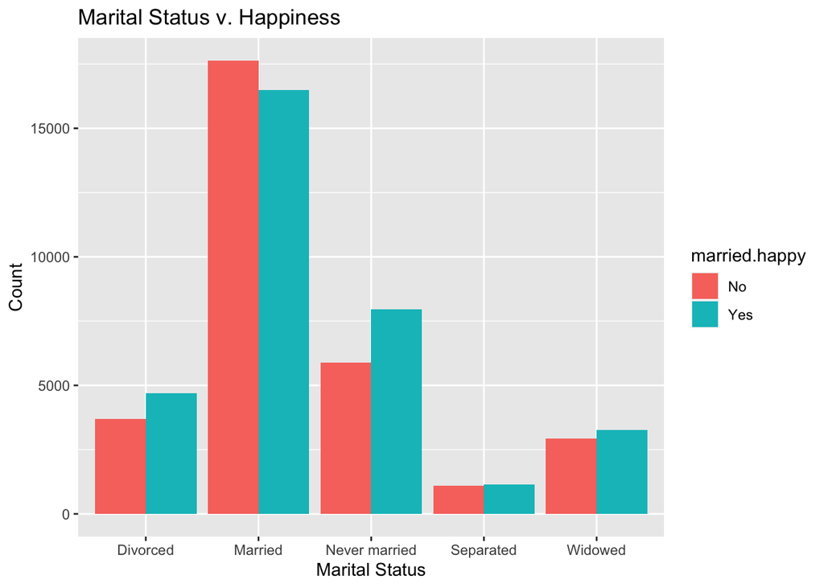

```r
dat2 <- filter(dat, marital != "No answer")
dat2 <- filter(dat2, marital != "NA")
dat2 <- mutate(dat2, married.happy = ifelse(happy == 'Very Happy' | happy == 'Pretty happy', 'Yes', 'No'))
ggplot(dat2, aes(x = marital, fill = married.happy)) + geom_bar(position = position_dodge()) + labs(x = "Marital Status", y = "Count", title = "Marital Status v. Happiness")
```

4. Does party affiliation affect the relationship you found in the last question?

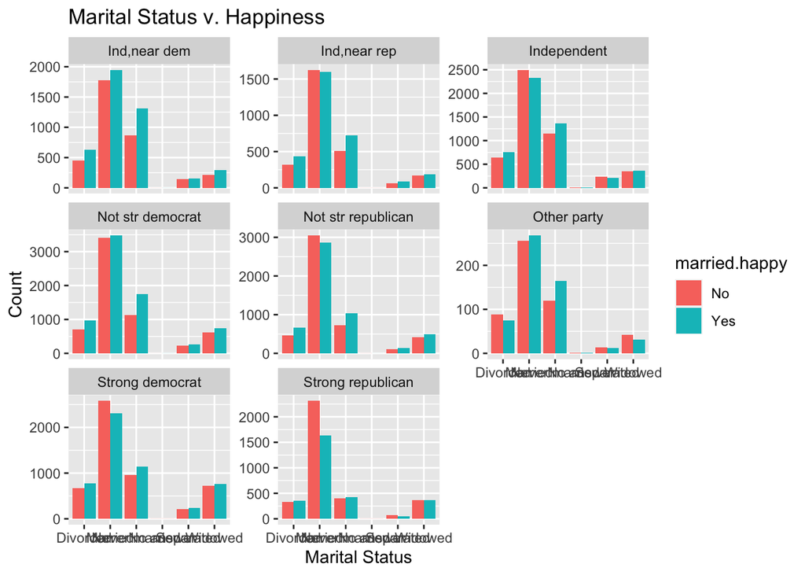

```r
dat3 <- filter(dat, political.party != "Don't know")
dat3 <- filter(dat3, political.party != "No answer")
dat3 <- mutate(dat3, married.happy = ifelse(happy == 'Very Happy' | happy == 'Pretty happy', 'Yes', 'No'))
ggplot(dat3, aes(x = marital, fill = married.happy)) + geom_bar(position = position_dodge()) + facet_wrap(~ political.party, scales = "free_y") + labs(x = "Marital Status", y = "Count", title = "Marital Status v. Happiness")
```

5. How is marital status related to the education of a respondent? What are possible reasons accounting for the patterns you see?

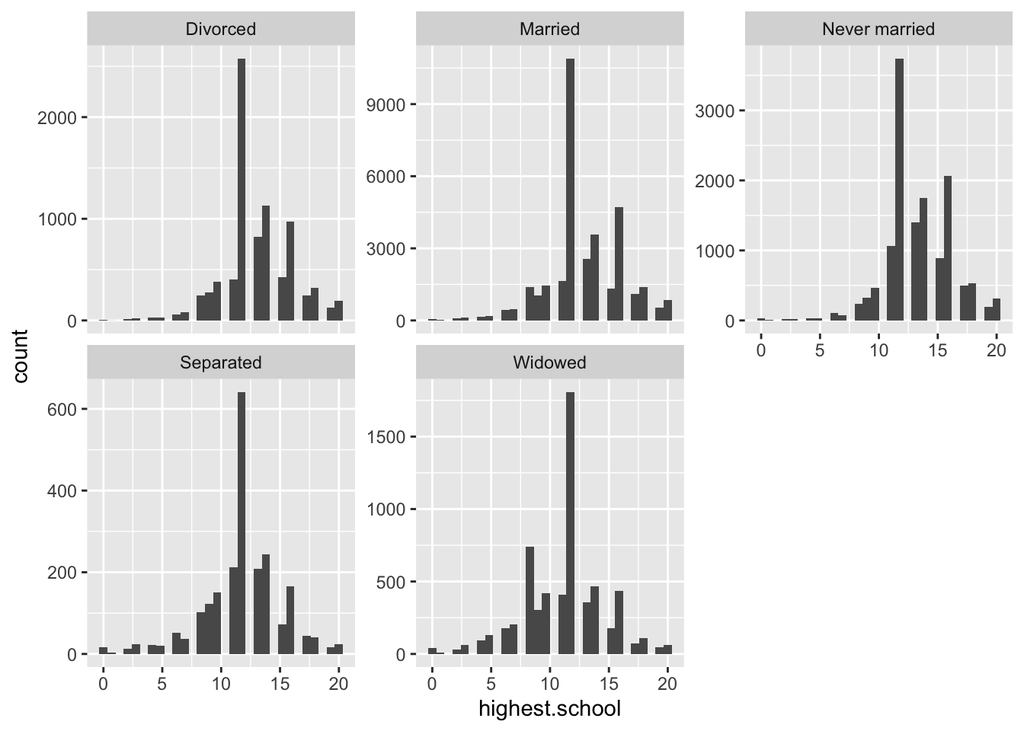

```r
dat4 <- filter(dat, marital != "NA")
dat4 <- filter(dat4, marital != "No answer")
ggplot(dat4, aes(x = highest.school)) + geom_histogram() + facet_wrap(~marital, scales = "free_y")
```

6. Explore two more interesting questions, and answer those questions using the GSS data.

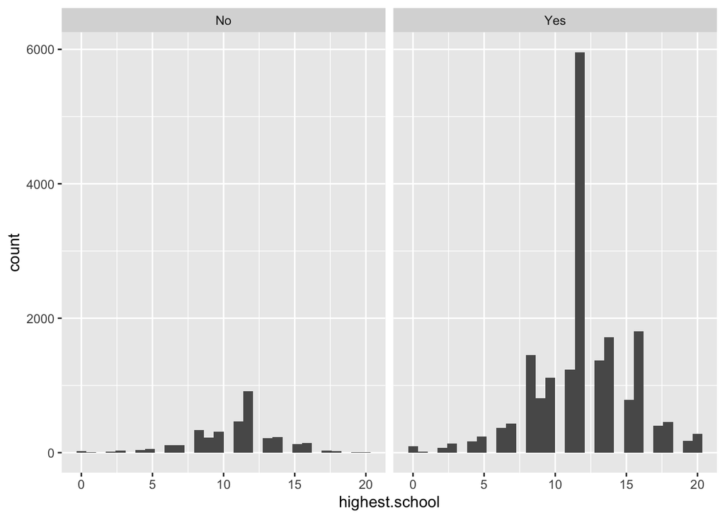

```r
dat5 <- filter(dat, work != "Don't know")
dat5 <- filter(dat5, work != "No answer")
dat5 <- filter(dat5, work != "Not applicable")
ggplot(dat5, aes(x = highest.school)) + geom_histogram() + facet_wrap(~work)
```